# Curve Fitting

Roadmap:

0. Install packages and load in data
1. Redo data manipulation
2. Fit dev rate curve to only successful pupations hourly
3. Fit dev rate curve to all larval-pupal intermediates and successful pupations hourly
4. Fit dev rate curve to all larval-pupal intermediates and successful pupations daily

#0. Load in packages and data

```r
library(remotes)
#remotes::install_github("padpadpadpad/rTPC")
library(rTPC)
library(nls.multstart)
library(Rmisc)
library(tidyverse)
library(broom)
library(purrr)
library(ggplot2)
library(ggpubr)
```

```r
Larvalcomb <- read.csv( "~/Desktop/GitHub/Pieris/NEWCombData.csv", header = TRUE)

Larvalcomb$Temperature <- Larvalcomb$Treatment
Larvalcomb$Treatment <- as.factor(Larvalcomb$Treatment)
Larvalcomb$Larv.Dev.Rate <- 1/Larvalcomb$Age.pupa
```

# 1. Redo data analysis

## Pupal mass

Including intermediates in larval analysis because we don’t include them in pupal analysis

### Mean mass and SE

```r
pupalmeans <- summarySE(data = Larvalcomb[Larvalcomb$Surv.pupa == "Y" & !is.na(Larvalcomb$Mass.pupa == TRUE), ], measurevar = "Mass.pupa", groupvars = c("Temperature", "Population"))

pupalmeans
```

| Temperature | Population | N | Mass.pupa | sd | se | ci |
| --- | --- | --- | --- | --- | --- | --- |
| 16 | CA | 68 | 194.7722 | 28.78037 | 3.490132 | 6.966333 |
| 16 | NC | 84 | 197.4646 | 34.16562 | 3.727775 | 7.414394 |
| 16 | WA | 38 | 184.5766 | 21.79231 | 3.535179 | 7.162953 |
| 21 | CA | 84 | 188.8657 | 25.78551 | 2.813430 | 5.595798 |
| 21 | NC | 95 | 198.5014 | 36.19473 | 3.713501 | 7.373244 |
| 21 | WA | 32 | 170.6262 | 25.24895 | 4.463426 | 9.103218 |
| 26 | CA | 49 | 165.6692 | 24.26853 | 3.466933 | 6.970736 |
| 26 | NC | 54 | 198.4752 | 31.21499 | 4.247822 | 8.520052 |
| 26 | WA | 35 | 160.7897 | 28.20330 | 4.767228 | 9.688172 |
| 30 | CA | 87 | 160.3244 | 17.11176 | 1.834573 | 3.647011 |

[output cut: 5 more lines]

```r
pupalmeans$Mass.se <- pupalmeans$se
pupalmeans$Mass.N <- pupalmeans$N

pupalmeans <- pupalmeans %>%
  select(Temperature, Population, Mass.N, Mass.pupa, Mass.se)
```

### Mean dev time and SE (EXCLUDING THIS FOR NOW)

```r
pupaltimemeans <- summarySE(data = data[data$Surv.pupa == "Y", ], measurevar = "Time.pupa", groupvars = c("Mean.Temp", "PupateOk"))
```

```
Error in data$Surv.pupa : object of type 'closure' is not subsettable
```

### Merge together (EXCLUDING THIS FOR NOW)

```r
pupalmeans <- merge(pupalmeans, pupaltimemeans, by = c("Mean.Temp", "PupateOk", "N"))
```

## Add in development rate

```r
pupalratemeans <- summarySE(data = Larvalcomb[Larvalcomb$Surv.pupa == "Y" & !is.na(Larvalcomb$Larv.Dev.Rate == TRUE), ], measurevar = "Larv.Dev.Rate", groupvars = c("Temperature", "Population"))

pupalratemeans
```

| Temperature | Population | N | Larv.Dev.Rate | sd | se | ci |
| --- | --- | --- | --- | --- | --- | --- |
| 16 | CA | 68 | 0.02977633 | 0.003643180 | 0.0004418005 | 0.0008818374 |
| 16 | NC | 85 | 0.02771393 | 0.002707112 | 0.0002936275 | 0.0005839105 |
| 16 | WA | 39 | 0.03039735 | 0.003698106 | 0.0005921709 | 0.0011987873 |
| 21 | CA | 84 | 0.04718997 | 0.005243523 | 0.0005721153 | 0.0011379143 |
| 21 | NC | 95 | 0.04418025 | 0.004769577 | 0.0004893482 | 0.0009716124 |
| 21 | WA | 33 | 0.05079506 | 0.005785304 | 0.0010070922 | 0.0020513797 |
| 26 | CA | 49 | 0.07168389 | 0.010081633 | 0.0014402333 | 0.0028957831 |
| 26 | NC | 54 | 0.08033669 | 0.008834384 | 0.0012022074 | 0.0024113227 |
| 26 | WA | 35 | 0.07283573 | 0.006868893 | 0.0011610547 | 0.0023595471 |
| 30 | CA | 87 | 0.08600860 | 0.012015648 | 0.0012882127 | 0.0025608821 |

[output cut: 5 more lines]

```r
pupalratemeans$Rate.se <- pupalratemeans$se
pupalratemeans$Rate.N <-pupalratemeans$N

pupalratemeans <- pupalratemeans %>%
  select(Temperature, Population, Rate.N, Larv.Dev.Rate, Rate.se)
```

```r
pupalmeans <- merge(pupalmeans, pupalratemeans, by = c("Temperature", "Population"))

pupalmeans
```

| Temperature | Population | Mass.N | Mass.pupa | Mass.se | Rate.N | Larv.Dev.Rate | Rate.se |
| --- | --- | --- | --- | --- | --- | --- | --- |
| 16 | CA | 68 | 194.7722 | 3.490132 | 68 | 0.02977633 | 0.0004418005 |
| 16 | NC | 84 | 197.4646 | 3.727775 | 85 | 0.02771393 | 0.0002936275 |
| 16 | WA | 38 | 184.5766 | 3.535179 | 39 | 0.03039735 | 0.0005921709 |
| 21 | CA | 84 | 188.8657 | 2.813430 | 84 | 0.04718997 | 0.0005721153 |
| 21 | NC | 95 | 198.5014 | 3.713501 | 95 | 0.04418025 | 0.0004893482 |
| 21 | WA | 32 | 170.6262 | 4.463426 | 33 | 0.05079506 | 0.0010070922 |
| 26 | CA | 49 | 165.6692 | 3.466933 | 49 | 0.07168389 | 0.0014402333 |
| 26 | NC | 54 | 198.4752 | 4.247822 | 54 | 0.08033669 | 0.0012022074 |
| 26 | WA | 35 | 160.7897 | 4.767228 | 35 | 0.07283573 | 0.0011610547 |
| 30 | CA | 87 | 160.3244 | 1.834573 | 87 | 0.08600860 | 0.0012882127 |

[output cut: 5 more lines]

## Pupal means combined with LPI and pupa (EXCLUDING FOR NOW)

```r
pupalmeanstotal <- summarySE(data = data[data$Surv.pupa == "Y", ], measurevar = "Mass.pupa", groupvars = c("Mean.Temp"))

pupalmeanstotal

pupalmeanstotal$Mass.se <- pupalmeanstotal$se

pupalmeanstotal <- pupalmeanstotal %>%
  select(Mean.Temp, N, Mass.pupa, Mass.se)
```

### Mean dev time and SE (EXCLUDING FOR NOW)

```r
pupaltimemeanstotal <- summarySE(data = data[data$Surv.pupa == "Y", ], measurevar = "Time.pupa", groupvars = c("Mean.Temp"))

pupaltimemeanstotal

pupaltimemeanstotal$Time.se <- pupaltimemeanstotal$se

pupaltimemeanstotal <- pupaltimemeanstotal %>%
  select(Mean.Temp, N, Time.pupa, Time.se)
```

### Merge together (EXCLUDING FOR NOW)

```r
pupalmeanstotal <- merge(pupalmeanstotal, pupaltimemeanstotal, by = c("Mean.Temp", "N"))
```

## Add in development rate (EXCLUDING FOR NOW)

```r
pupalratemeanstotal <- summarySE(data = data[data$Surv.pupa == "Y", ], measurevar = "Dev.Rate", groupvars = c("Mean.Temp"))

pupalratemeanstotal

pupalratemeanstotal$Rate.se <- pupalratemeanstotal$se

pupalratemeanstotal <- pupalratemeanstotal %>%
  select(Mean.Temp, N, Dev.Rate, Rate.se)
```

```r
pupalmeanstotal <- merge(pupalmeanstotal, pupalratemeanstotal, by = c("Mean.Temp", "N"))
```

## Survival to pupation vs temp treatment

1. Create summary table
2. Create blank table for input
3. Hard code input
4. Graph it

### 1. Create summary table

```r
survpercsum <- summarySE(data = data,
                         measurevar = "Mass.pupa",
                         groupvars = c("Mean.Temp", "Surv.pupa"))
```

```
Error in if (empty(.data)) return(.data) :
  missing value where TRUE/FALSE needed
```

### 2. Create blank table

```r
survdata <- data.frame(Mean.Temp = c(16, 21, 26, 30, 34),
                       surv.perc = 0,
                       group = 1)

survdata$Mean.Temp <- as.factor(survdata$Mean.Temp)
survdata$group = as.factor(survdata$group)
```

### 3. Hard code it

```r
survdata[1, 2] <- survpercsum[2, 3] / (survpercsum[2, 3] + survpercsum[1, 3])
survdata[2, 2] <- survpercsum[4, 3] / (survpercsum[4, 3] + survpercsum[3, 3])
survdata[3, 2] <- survpercsum[6, 3] / (survpercsum[6, 3] + survpercsum[5, 3])
survdata[4, 2] <- survpercsum[8, 3] / (survpercsum[8, 3] + survpercsum[7, 3])
survdata[5, 2] <- survpercsum[10, 3] / (survpercsum[10, 3] + survpercsum[9, 3])
```

# 2. Fit dev rate curve just for successful pupa and intermediates using rTPC

Change temp to not be a factor

```r
#pupalmeans$Mean.Temp <- as.character(pupalmeans$Mean.Temp)
##pupalmeans$Mean.Temp <- as.numeric(pupalmeans$Mean.Temp)

#pupalmeansyes <- pupalmeans[pupalmeans$PupateOk == "Y", ]
```

## For NC first…

[output not shown]

[output cut: 5 more lines]

.

```r
NCpupalmeans <- pupalmeans[pupalmeans$Population == "NC", ]
```

```r
fitmodgaussNC <- nls_multstart(data = NCpupalmeans[, c(1, 7)],
                             Larv.Dev.Rate ~ modifiedgaussian_2006(temp = Temperature, rmax, topt, a, b),
                             iter = c(5, 5, 5, 5),
                             start_lower = get_start_vals(NCpupalmeans$Temperature, NCpupalmeans$Larv.Dev.Rate,
                                                          model_name = "modifiedgaussian_2006") - 10,
                             start_upper = get_start_vals(NCpupalmeans$Temperature, NCpupalmeans$Larv.Dev.Rate,
                                                          model_name = "modifiedgaussian_2006") + 10,
                             lower = get_lower_lims(NCpupalmeans$Temperature, NCpupalmeans$Larv.Dev.Rate,
                                                    model_name = "modifiedgaussian_2006"),
                             upper = get_upper_lims(NCpupalmeans$Temperature, NCpupalmeans$Larv.Dev.Rate,
                                                    model_name = "modifiedgaussian_2006"))
```

[output not shown]

[output cut: 801 more lines]

[output not shown]

```r
summary(fitmodgaussNC)
```

```
Formula: Larv.Dev.Rate ~ modifiedgaussian_2006(temp = Temperature, rmax,
    topt, a, b)

Parameters:
      Estimate Std. Error t value Pr(>|t|)
rmax  0.098500   0.007238  13.608  0.04670 *
topt 28.982710   0.334636  86.610  0.00735 **
a     5.804283   1.003972   5.781  0.10904
b     1.214586   0.248395   4.890  0.12842
---
Signif. codes:  0 ‘***’ 0.001 ‘**’ 0.01 ‘*’ 0.05 ‘.’ 0.1 ‘ ’ 1

Residual standard error: 0.00394 on 1 degrees of freedom

Number of iterations to convergence: 15
Achieved convergence tolerance: 1.49e-08
```

## Modifying Lauren Buckley’s code

```r
NCd <- as.data.frame(cbind(NCpupalmeans$Temperature, NCpupalmeans$Larv.Dev.Rate))

colnames(NCd) <- c("temp", "rate")
```

```r
d_fits <- nest(NCd, data = c(temp, rate)) %>%
  mutate(modified_gaussian = map(data, ~nls_multstart(rate~modifiedgaussian_2006(temp = temp, rmax, topt, a, b),
                                         data = .x,
                                         iter = c(4,4,4,4),
                                         start_lower = get_start_vals(.x$temp, .x$rate,
                                                                      model_name = 'modifiedgaussian_2006') - 10,
                                         start_upper = get_start_vals(.x$temp, .x$rate,
                                                                      model_name = 'modifiedgaussian_2006') + 10,
                                         lower = get_lower_lims(.x$temp, .x$rate, model_name = 'modifiedgaussian_2006'),
                                         upper = get_upper_lims(.x$temp, .x$rate, model_name = 'modifiedgaussian_2006'),
                                         supp_errors = 'Y',
                                         convergence_count = FALSE)),
         rezende = map(data, ~nls_multstart(rate~rezende_2019(temp = temp, q10, a, b, c),
                                             data = .x,
                                             iter = c(4,4,4,4),
                                             start_lower = get_start_vals(.x$temp, .x$rate, model_name = 'rezende_2019') - 10,
                                             start_upper = get_start_vals(.x$temp, .x$rate, model_name = 'rezende_2019') + 10,
                                             lower = get_lower_lims(.x$temp, .x$rate, model_name = 'rezende_2019'),
                                             upper = get_upper_lims(.x$temp, .x$rate, model_name = 'rezende_2019'),
                                             supp_errors = 'Y',
                                             convergence_count = FALSE)),

         sharpeschool =  map(data, ~nls_multstart(rate~sharpeschoolfull_1981(temp = temp, r_tref, e, el, tl, eh, th, tref=29),
                                             data = .x,
                                             iter = c(4,4,4,4,4,4),
                                             start_lower = get_start_vals(.x$temp, .x$rate,
                                                                          model_name = 'sharpeschoolfull_1981') - 10,
                                             start_upper = get_start_vals(.x$temp, .x$rate,
                                                                          model_name = 'sharpeschoolfull_1981') + 10,
                                             lower = get_lower_lims(.x$temp, .x$rate, model_name = 'sharpeschoolfull_1981'),
                                             upper = get_upper_lims(.x$temp, .x$rate, model_name = 'sharpeschoolfull_1981'),
                                             supp_errors = 'Y',
                                             convergence_count = FALSE)),
         weibull = map(data, ~nls_multstart(rate~weibull_1995(temp = temp, a,topt,b,c),
                                            data = .x,
                                            iter = c(4,4,4,4),
                                            start_lower = get_start_vals(.x$temp, .x$rate, model_name = 'weibull_1995') - 10,
                                            start_upper = get_start_vals(.x$temp, .x$rate, model_name = 'weibull_1995') + 10,
                                            lower = get_lower_lims(.x$temp, .x$rate, model_name = 'weibull_1995'),
                                            upper = get_upper_lims(.x$temp, .x$rate, model_name = 'weibull_1995'),
                                            supp_errors = 'Y',
                                            convergence_count = FALSE)))
# stack models
d_stack <- select(d_fits, -data) %>%
  pivot_longer(., names_to = 'model_name', values_to = 'fit', modified_gaussian:weibull)

# get parameters using tidy (no longer working)
#params <- d_stack %>%
  #mutate(., est = map(fit, tidy)) %>%
  #select(-fit) %>%
  #unnest(est)

# get predictions using augment
newdata <- tibble(temp = seq(min(NCd$temp), max(NCd$temp), length.out = 100))
d_preds <- d_stack %>%
  mutate(., preds = map(fit, augment, newdata = newdata)) %>%
  select(-fit) %>%
  unnest(preds)
```

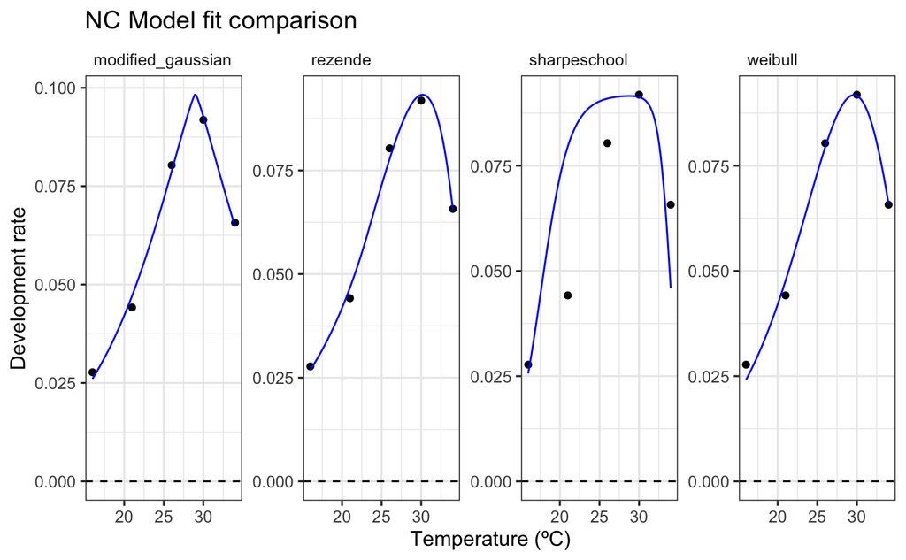

```r
# plot fits
NCMODS <- ggplot(d_preds, aes(temp, rate)) +
  geom_point(aes(temp, rate), NCd) +
  geom_line(aes(temp, .fitted), col = 'blue') +
  facet_wrap(~model_name, scales = 'free', ncol = 5) +
  theme_bw(base_size = 12) +
  theme(legend.position = 'none',
        strip.text = element_text(hjust = 0),
        strip.background = element_blank()) +
  labs(x = 'Temperature (ºC)',
       y = 'Development rate',
       title = 'NC Model fit comparison') +
  geom_hline(aes(yintercept = 0), linetype = 2)

NCMODS
```

```r
ggsave("~/Desktop/GitHub/Pieris/Thesis/NCModels.png", NCMODS, width = 8, height = 5)
```

## Compare models using AIC

```r
AIC(d_fits[[2]][[1]],d_fits[[3]][[1]], d_fits[[4]][[1]], d_fits[[5]][[1]])
```

|  | df | AIC |
| --- | --- | --- |
| d_fits[[2]][[1]] | 5 | -39.22352 |
| d_fits[[3]][[1]] | 5 | -39.07988 |
| d_fits[[4]][[1]] | 7 | -11.57189 |
| d_fits[[5]][[1]] | 5 | -36.58028 |

Now let’s predict to the x-axis and graph that.

```r
toxaxis <- tibble(temp = seq((-5), 50, length.out = 200))

d_preds_two <- d_stack %>%
  mutate(., preds = map(fit, augment, newdata = toxaxis)) %>%
  select(-fit) %>%
  unnest(preds)
```

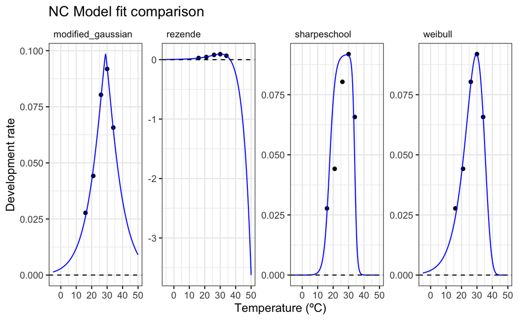

```r
NCMODS2 <- ggplot(d_preds_two, aes(temp, rate)) +
  geom_point(aes(temp, rate), NCd) +
  geom_line(aes(temp, .fitted), col = 'blue') +
  facet_wrap(~model_name, scales = 'free', ncol = 5) +
  theme_bw(base_size = 12) +
  theme(legend.position = 'none',
        strip.text = element_text(hjust = 0),
        strip.background = element_blank()) +
  labs(x = 'Temperature (ºC)',
       y = 'Development rate',
       title = 'NC Model fit comparison') +
  geom_hline(aes(yintercept = 0), linetype = 2)

NCMODS2
```

## Graphing two best models for NC

```r
modGR <-ggplot(d_preds_two[c(201:400, 601:800), ], aes(temp, rate)) +
  geom_point(aes(temp, rate), NCd, color = "black") +
  geom_line(aes(temp, .fitted)) +
  facet_wrap(~model_name, scales = 'free', ncol = 5) +
  theme_bw(base_size = 12) +
  theme(legend.position = 'none',
        strip.text = element_text(hjust = 0),
        strip.background = element_blank()) +
  labs(x = 'Temperature (ºC)',
       y = 'Development rate',
       title = 'Gaussian and Rezende Model For Development Rate') +
  ylim(-.01, .1)+
  geom_hline(aes(yintercept = 0), linetype = 2) +

modGR
```

```r
ggsave("~/Desktop/GitHub/Pieris/Figures/modweibull.png", modweibull, width = 8, height = 5)
```

## Getting the final dev rate curve

```r
NCfitmodweibull <- nls_multstart(data = NCpupalmeans[, c(1, 7)],
                             Larv.Dev.Rate ~ weibull_1995(temp = Temperature, a, topt, b, c),
                             iter = c(4, 4, 4, 4),
                             start_lower = get_start_vals(NCpupalmeans$Temperature, NCpupalmeans$Larv.Dev.Rate,
                                                          model_name = "weibull_1995") - 10,
                             start_upper = get_start_vals(NCpupalmeans$Temperature, NCpupalmeans$Larv.Dev.Rate,
                                                          model_name = "weibull_1995") + 10,
                             lower = get_lower_lims(NCpupalmeans$Temperature, NCpupalmeans$Larv.Dev.Rate,
                                                    model_name = "weibull_1995"),
                             upper = get_upper_lims(NCpupalmeans$Temperature, NCpupalmeans$Larv.Dev.Rate,
                                                    model_name = "weibull_1995"),
                             supp_errors = 'Y',
                             convergence_count = FALSE)
```

```r
summary(NCfitmodweibull)
```

```
Formula: Larv.Dev.Rate ~ weibull_1995(temp = Temperature, a, topt, b,
    c)

Parameters:
      Estimate Std. Error t value Pr(>|t|)
a    9.180e-02  5.361e-03  17.122   0.0371 *
topt 2.962e+01  5.229e-01  56.655   0.0112 *
b    3.194e+05  3.402e+08   0.001   0.9994
c    5.224e+04  5.566e+07   0.001   0.9994
---
Signif. codes:  0 ‘***’ 0.001 ‘**’ 0.01 ‘*’ 0.05 ‘.’ 0.1 ‘ ’ 1

Residual standard error: 0.005132 on 1 degrees of freedom

Number of iterations to convergence: 38
Achieved convergence tolerance: 1.49e-08
```

```r
NCfitmodrezende <- nls_multstart(data = NCpupalmeans[, c(1, 7)],
                             Larv.Dev.Rate ~ rezende_2019(temp = Temperature, a, topt, b, c),
                             iter = c(4, 4, 4, 4),
                             start_lower = get_start_vals(NCpupalmeans$Temperature, NCpupalmeans$Larv.Dev.Rate,
                                                          model_name = "rezende_2019") - 10,
                             start_upper = get_start_vals(NCpupalmeans$Temperature, NCpupalmeans$Larv.Dev.Rate,
                                                          model_name = "rezende_2019") + 10,
                             lower = get_lower_lims(NCpupalmeans$Temperature, NCpupalmeans$Larv.Dev.Rate,
                                                    model_name = "rezende_2019"),
                             upper = get_upper_lims(NCpupalmeans$Temperature, NCpupalmeans$Larv.Dev.Rate,
                                                    model_name = "rezende_2019"),
                             supp_errors = 'Y',
                             convergence_count = FALSE)
```

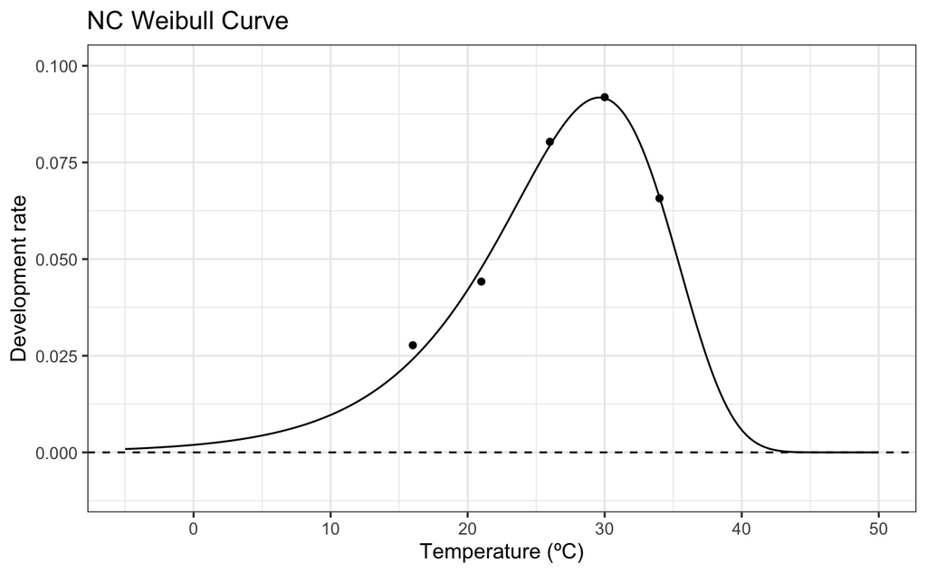

```r
NCWeibull <- ggplot(d_preds_two[c(601:800), ], aes(temp, rate)) +
  geom_point(aes(temp, rate), NCd, color = "black") +
  geom_line(aes(temp, .fitted)) +
  theme_bw(base_size = 12) +
  labs(x = 'Temperature (ºC)',
       y = 'Development rate',
       title = 'NC Weibull Curve') +
  ylim(-.01, .1)+
  geom_hline(aes(yintercept = 0), linetype = 2)

NCWeibull
```

## Now for California

```r
CApupalmeans <- pupalmeans[pupalmeans$Population == "CA", ]
```

```r
fitmodgaussCA <- nls_multstart(data = CApupalmeans[, c(1, 7)],
                             Larv.Dev.Rate ~ modifiedgaussian_2006(temp = Temperature, rmax, topt, a, b),
                             iter = c(5, 5, 5, 5),
                             start_lower = get_start_vals(CApupalmeans$Temperature, CApupalmeans$Larv.Dev.Rate,
                                                          model_name = "modifiedgaussian_2006") - 10,
                             start_upper = get_start_vals(CApupalmeans$Temperature, CApupalmeans$Larv.Dev.Rate,
                                                          model_name = "modifiedgaussian_2006") + 10,
                             lower = get_lower_lims(CApupalmeans$Temperature, CApupalmeans$Larv.Dev.Rate,
                                                    model_name = "modifiedgaussian_2006"),
                             upper = get_upper_lims(CApupalmeans$Temperature, CApupalmeans$Larv.Dev.Rate,
                                                    model_name = "modifiedgaussian_2006"))
```

```r
summary(fitmodgaussCA)
```

```
Formula: Larv.Dev.Rate ~ modifiedgaussian_2006(temp = Temperature, rmax,
    topt, a, b)

Parameters:
      Estimate Std. Error t value Pr(>|t|)
rmax  0.086365   0.001138   75.86  0.00839 **
topt 30.145397   0.162495  185.52  0.00343 **
a     8.152876   0.258010   31.60  0.02014 *
b     1.398881   0.073655   18.99  0.03349 *
---
Signif. codes:  0 ‘***’ 0.001 ‘**’ 0.01 ‘*’ 0.05 ‘.’ 0.1 ‘ ’ 1

Residual standard error: 0.001116 on 1 degrees of freedom

Number of iterations to convergence: 11
Achieved convergence tolerance: 1.49e-08
```

```r
CAd <- as.data.frame(cbind(CApupalmeans$Temperature, CApupalmeans$Larv.Dev.Rate))

colnames(CAd) <- c("temp", "rate")
```

```r
CA_d_fits <- nest(CAd, data = c(temp, rate)) %>%
  mutate(modified_gaussian = map(data, ~nls_multstart(rate~modifiedgaussian_2006(temp = temp, rmax, topt, a, b),
                                         data = .x,
                                         iter = c(4,4,4,4),
                                         start_lower = get_start_vals(.x$temp, .x$rate,
                                                                      model_name = 'modifiedgaussian_2006') - 10,
                                         start_upper = get_start_vals(.x$temp, .x$rate,
                                                                      model_name = 'modifiedgaussian_2006') + 10,
                                         lower = get_lower_lims(.x$temp, .x$rate, model_name = 'modifiedgaussian_2006'),
                                         upper = get_upper_lims(.x$temp, .x$rate, model_name = 'modifiedgaussian_2006'),
                                         supp_errors = 'Y',
                                         convergence_count = FALSE)),
         rezende = map(data, ~nls_multstart(rate~rezende_2019(temp = temp, q10, a, b, c),
                                             data = .x,
                                             iter = c(4,4,4,4),
                                             start_lower = get_start_vals(.x$temp, .x$rate, model_name = 'rezende_2019') - 10,
                                             start_upper = get_start_vals(.x$temp, .x$rate, model_name = 'rezende_2019') + 10,
                                             lower = get_lower_lims(.x$temp, .x$rate, model_name = 'rezende_2019'),
                                             upper = get_upper_lims(.x$temp, .x$rate, model_name = 'rezende_2019'),
                                             supp_errors = 'Y',
                                             convergence_count = FALSE)),

         sharpeschool =  map(data, ~nls_multstart(rate~sharpeschoolfull_1981(temp = temp, r_tref, e, el, tl, eh, th, tref=29),
                                             data = .x,
                                             iter = c(4,4,4,4,4,4),
                                             start_lower = get_start_vals(.x$temp, .x$rate,
                                                                          model_name = 'sharpeschoolfull_1981') - 10,
                                             start_upper = get_start_vals(.x$temp, .x$rate,
                                                                          model_name = 'sharpeschoolfull_1981') + 10,
                                             lower = get_lower_lims(.x$temp, .x$rate, model_name = 'sharpeschoolfull_1981'),
                                             upper = get_upper_lims(.x$temp, .x$rate, model_name = 'sharpeschoolfull_1981'),
                                             supp_errors = 'Y',
                                             convergence_count = FALSE)),
         weibull = map(data, ~nls_multstart(rate~weibull_1995(temp = temp, a,topt,b,c),
                                            data = .x,
                                            iter = c(4,4,4,4),
                                            start_lower = get_start_vals(.x$temp, .x$rate, model_name = 'weibull_1995') - 10,
                                            start_upper = get_start_vals(.x$temp, .x$rate, model_name = 'weibull_1995') + 10,
                                            lower = get_lower_lims(.x$temp, .x$rate, model_name = 'weibull_1995'),
                                            upper = get_upper_lims(.x$temp, .x$rate, model_name = 'weibull_1995'),
                                            supp_errors = 'Y',
                                            convergence_count = FALSE)))
# stack models
CA_d_stack <- select(CA_d_fits, -data) %>%
  pivot_longer(., names_to = 'model_name', values_to = 'fit', modified_gaussian:weibull)

# get parameters using tidy (no longer working)
#params <- d_stack %>%
  #mutate(., est = map(fit, tidy)) %>%
  #select(-fit) %>%
  #unnest(est)

# get predictions using augment
newdata <- tibble(temp = seq(min(CAd$temp), max(CAd$temp), length.out = 100))
CA_d_preds <- CA_d_stack %>%
  mutate(., preds = map(fit, augment, newdata = newdata)) %>%
  select(-fit) %>%
  unnest(preds)
```

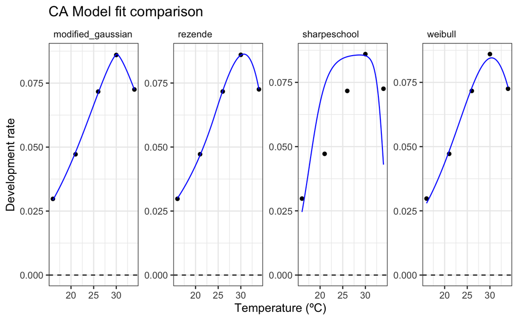

```r
# plot fits
CAMODS <- ggplot(CA_d_preds, aes(temp, rate)) +
  geom_point(aes(temp, rate), CAd) +
  geom_line(aes(temp, .fitted), col = 'blue') +
  facet_wrap(~model_name, scales = 'free', ncol = 5) +
  theme_bw(base_size = 12) +
  theme(legend.position = 'none',
        strip.text = element_text(hjust = 0),
        strip.background = element_blank()) +
  labs(x = 'Temperature (ºC)',
       y = 'Development rate',
       title = 'CA Model fit comparison') +
  geom_hline(aes(yintercept = 0), linetype = 2)

CAMODS
```

```r
ggsave("~/Desktop/GitHub/Pieris/Thesis/CAModels.png", CAMODS, width = 8, height = 5)
```

```r
AIC(CA_d_fits[[2]][[1]],CA_d_fits[[3]][[1]], CA_d_fits[[4]][[1]], CA_d_fits[[5]][[1]])
```

|  | df | AIC |
| --- | --- | --- |
| CA_d_fits[[2]][[1]] | 5 | -51.83439 |
| CA_d_fits[[3]][[1]] | 5 | -59.57186 |
| CA_d_fits[[4]][[1]] | 7 | -11.49473 |
| CA_d_fits[[5]][[1]] | 5 | -42.07975 |

```r
toxaxis <- tibble(temp = seq((-5), 50, length.out = 200))

CA_d_preds_two <- CA_d_stack %>%
  mutate(., preds = map(fit, augment, newdata = toxaxis)) %>%
  select(-fit) %>%
  unnest(preds)
```

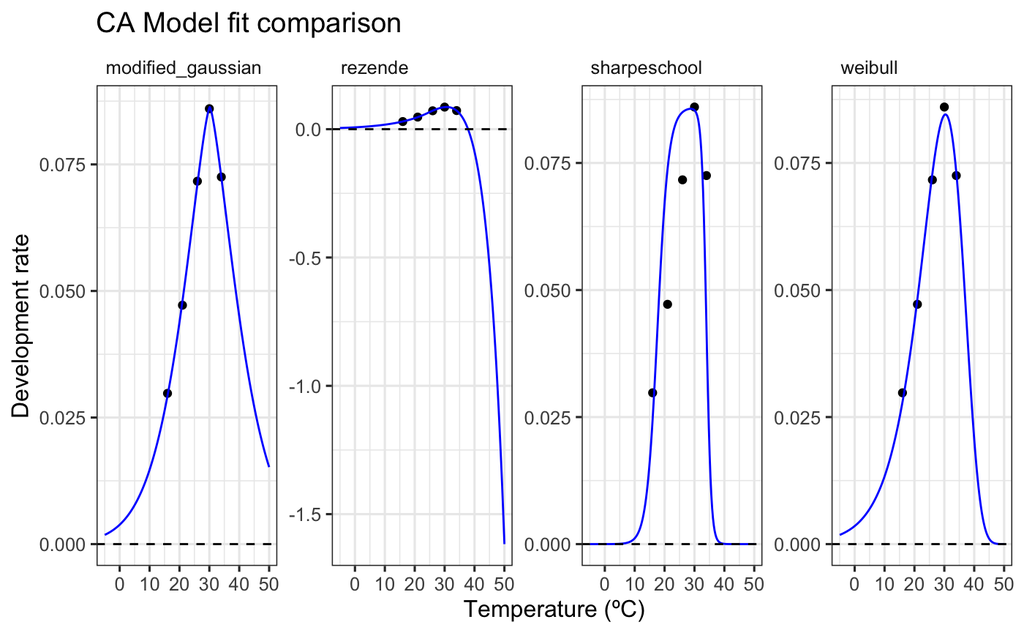

```r
CAMODS2 <- ggplot(CA_d_preds_two, aes(temp, rate)) +
  geom_point(aes(temp, rate), CAd) +
  geom_line(aes(temp, .fitted), col = 'blue') +
  facet_wrap(~model_name, scales = 'free', ncol = 5) +
  theme_bw(base_size = 12) +
  theme(legend.position = 'none',
        strip.text = element_text(hjust = 0),
        strip.background = element_blank()) +
  labs(x = 'Temperature (ºC)',
       y = 'Development rate',
       title = 'CA Model fit comparison') +
  geom_hline(aes(yintercept = 0), linetype = 2)

CAMODS2
```

```r
ggsave("~/Desktop/GitHub/Pieris/Thesis/CAModels2.png", CAMODS2, width = 8, height = 5)
```

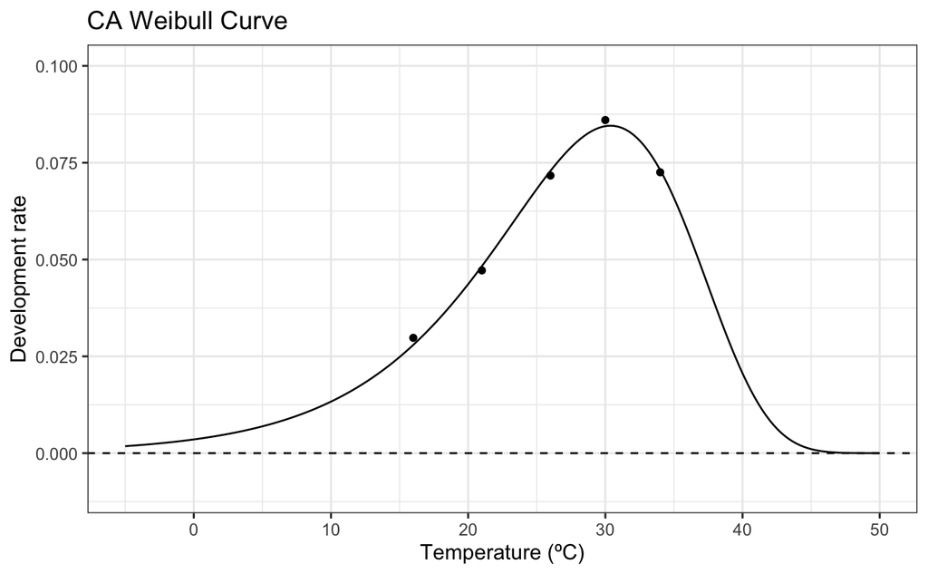

```r
CAWeibull <- ggplot(CA_d_preds_two[c(601:800), ], aes(temp, rate)) +
  geom_point(aes(temp, rate), CAd, color = "black") +
  geom_line(aes(temp, .fitted)) +
  theme_bw(base_size = 12) +
  labs(x = 'Temperature (ºC)',
       y = 'Development rate',
       title = 'CA Weibull Curve') +
  ylim(-.01, .1)+
  geom_hline(aes(yintercept = 0), linetype = 2)

CAWeibull
```

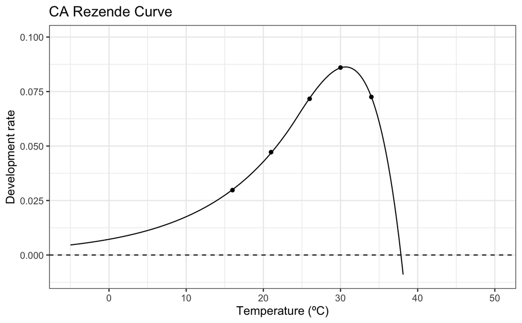

```r
CARezende <- ggplot(CA_d_preds_two[c(201:400), ], aes(temp, rate)) +
  geom_point(aes(temp, rate), CAd, color = "black") +
  geom_line(aes(temp, .fitted)) +
  theme_bw(base_size = 12) +
  labs(x = 'Temperature (ºC)',
       y = 'Development rate',
       title = 'CA Rezende Curve') +
  ylim(-.01, .1)+
  geom_hline(aes(yintercept = 0), linetype = 2)

CARezende
```

## Finally for Washington

```r
WApupalmeans <- pupalmeans[pupalmeans$Population == "WA", ]
```

```r
fitmodgaussWA <- nls_multstart(data = WApupalmeans[, c(1, 7)],
                             Larv.Dev.Rate ~ modifiedgaussian_2006(temp = Temperature, rmax, topt, a, b),
                             iter = c(5, 5, 5, 5),
                             start_lower = get_start_vals(WApupalmeans$Temperature, WApupalmeans$Larv.Dev.Rate,
                                                          model_name = "modifiedgaussian_2006") - 10,
                             start_upper = get_start_vals(WApupalmeans$Temperature, WApupalmeans$Larv.Dev.Rate,
                                                          model_name = "modifiedgaussian_2006") + 10,
                             lower = get_lower_lims(WApupalmeans$Temperature, WApupalmeans$Larv.Dev.Rate,
                                                    model_name = "modifiedgaussian_2006"),
                             upper = get_upper_lims(WApupalmeans$Temperature, WApupalmeans$Larv.Dev.Rate,
                                                    model_name = "modifiedgaussian_2006"))
```

```r
summary(fitmodgaussWA)
```

[output not shown]

```r
WAd <- as.data.frame(cbind(WApupalmeans$Temperature, WApupalmeans$Larv.Dev.Rate))

colnames(WAd) <- c("temp", "rate")
```

```r
WA_d_fits <- nest(WAd, data = c(temp, rate)) %>%
  mutate(modified_gaussian = map(data, ~nls_multstart(rate~modifiedgaussian_2006(temp = temp, rmax, topt, a, b),
                                         data = .x,
                                         iter = c(4,4,4,4),
                                         start_lower = get_start_vals(.x$temp, .x$rate,
                                                                      model_name = 'modifiedgaussian_2006') - 10,
                                         start_upper = get_start_vals(.x$temp, .x$rate,
                                                                      model_name = 'modifiedgaussian_2006') + 10,
                                         lower = get_lower_lims(.x$temp, .x$rate, model_name = 'modifiedgaussian_2006'),
                                         upper = get_upper_lims(.x$temp, .x$rate, model_name = 'modifiedgaussian_2006'),
                                         supp_errors = 'Y',
                                         convergence_count = FALSE)),
         rezende = map(data, ~nls_multstart(rate~rezende_2019(temp = temp, q10, a, b, c),
                                             data = .x,
                                             iter = c(4,4,4,4),
                                             start_lower = get_start_vals(.x$temp, .x$rate, model_name = 'rezende_2019') - 10,
                                             start_upper = get_start_vals(.x$temp, .x$rate, model_name = 'rezende_2019') + 10,
                                             lower = get_lower_lims(.x$temp, .x$rate, model_name = 'rezende_2019'),
                                             upper = get_upper_lims(.x$temp, .x$rate, model_name = 'rezende_2019'),
                                             supp_errors = 'Y',
                                             convergence_count = FALSE)),

         sharpeschool =  map(data, ~nls_multstart(rate~sharpeschoolfull_1981(temp = temp, r_tref, e, el, tl, eh, th, tref=29),
                                             data = .x,
                                             iter = c(4,4,4,4,4,4),
                                             start_lower = get_start_vals(.x$temp, .x$rate,
                                                                          model_name = 'sharpeschoolfull_1981') - 10,
                                             start_upper = get_start_vals(.x$temp, .x$rate,
                                                                          model_name = 'sharpeschoolfull_1981') + 10,
                                             lower = get_lower_lims(.x$temp, .x$rate, model_name = 'sharpeschoolfull_1981'),
                                             upper = get_upper_lims(.x$temp, .x$rate, model_name = 'sharpeschoolfull_1981'),
                                             supp_errors = 'Y',
                                             convergence_count = FALSE)),
         weibull = map(data, ~nls_multstart(rate~weibull_1995(temp = temp, a,topt,b,c),
                                            data = .x,
                                            iter = c(4,4,4,4),
                                            start_lower = get_start_vals(.x$temp, .x$rate, model_name = 'weibull_1995') - 10,
                                            start_upper = get_start_vals(.x$temp, .x$rate, model_name = 'weibull_1995') + 10,
                                            lower = get_lower_lims(.x$temp, .x$rate, model_name = 'weibull_1995'),
                                            upper = get_upper_lims(.x$temp, .x$rate, model_name = 'weibull_1995'),
                                            supp_errors = 'Y',
                                            convergence_count = FALSE)))
# stack models
WA_d_stack <- select(WA_d_fits, -data) %>%
  pivot_longer(., names_to = 'model_name', values_to = 'fit', modified_gaussian:weibull)

# get parameters using tidy (no longer working)
#params <- d_stack %>%
  #mutate(., est = map(fit, tidy)) %>%
  #select(-fit) %>%
  #unnest(est)

# get predictions using augment
newdata <- tibble(temp = seq(min(CAd$temp), max(CAd$temp), length.out = 100))
WA_d_preds <- WA_d_stack %>%
  mutate(., preds = map(fit, augment, newdata = newdata)) %>%
  select(-fit) %>%
  unnest(preds)
```

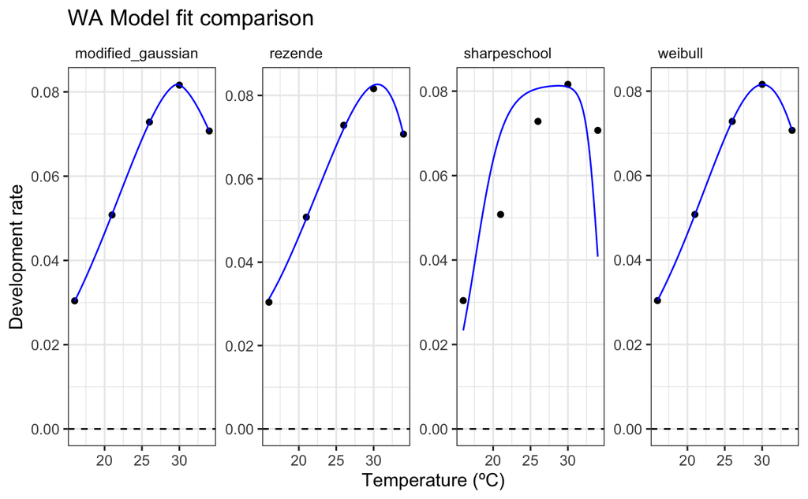

```r
# plot fits
WAMODS <- ggplot(WA_d_preds, aes(temp, rate)) +
  geom_point(aes(temp, rate), WAd) +
  geom_line(aes(temp, .fitted), col = 'blue') +
  facet_wrap(~model_name, scales = 'free', ncol = 5) +
  theme_bw(base_size = 12) +
  theme(legend.position = 'none',
        strip.text = element_text(hjust = 0),
        strip.background = element_blank()) +
  labs(x = 'Temperature (ºC)',
       y = 'Development rate',
       title = 'WA Model fit comparison') +
  geom_hline(aes(yintercept = 0), linetype = 2)

WAMODS
```

```r
ggsave("~/Desktop/GitHub/Pieris/Thesis/WAModels.png", WAMODS, width = 8, height = 5)
```

[output not shown]

```r
toxaxis <- tibble(temp = seq((-5), 50, length.out = 200))

WA_d_preds_two <- WA_d_stack %>%
  mutate(., preds = map(fit, augment, newdata = toxaxis)) %>%
  select(-fit) %>%
  unnest(preds)
```

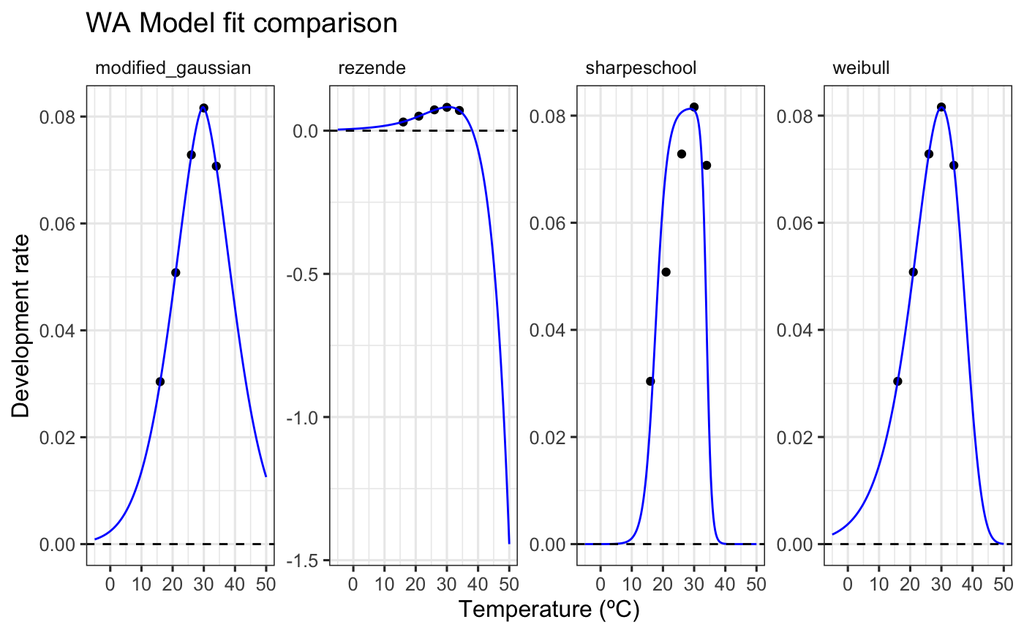

```r
WAMODS2 <- ggplot(WA_d_preds_two, aes(temp, rate)) +
  geom_point(aes(temp, rate), WAd) +
  geom_line(aes(temp, .fitted), col = 'blue') +
  facet_wrap(~model_name, scales = 'free', ncol = 5) +
  theme_bw(base_size = 12) +
  theme(legend.position = 'none',
        strip.text = element_text(hjust = 0),
        strip.background = element_blank()) +
  labs(x = 'Temperature (ºC)',
       y = 'Development rate',
       title = 'WA Model fit comparison') +
  geom_hline(aes(yintercept = 0), linetype = 2)

WAMODS2
```

```r
ggsave("~/Desktop/GitHub/Pieris/Thesis/WAModels2.png", WAMODS2, width = 8, height = 5)
```

[figure not shown]

[figure not shown]

## Now I want to overlap all three weibull curves for the populations and all three rezende curves for the populations

```r
WA_d_preds_two$Population <- "WA"
d_preds_two$Population <- "NC"
CA_d_preds_two$Population <- "CA"

AllPopWeibull <- rbind(WA_d_preds_two[c(601:800), ], d_preds_two[c(601:800), ])
AllPopWeibull <-rbind(AllPopWeibull, CA_d_preds_two[c(601:800), ])

AllPopRezende <- rbind(WA_d_preds_two[c(201:400), ], d_preds_two[c(201:400), ])
AllPopRezende <- rbind(AllPopRezende, CA_d_preds_two[c(201:400), ])

CAd$Population <- "CA"
NCd$Population <- "NC"
WAd$Population <- "WA"
AllPopPoints <- rbind(CAd, NCd)
AllPopPoints <- rbind(AllPopPoints, WAd)
```

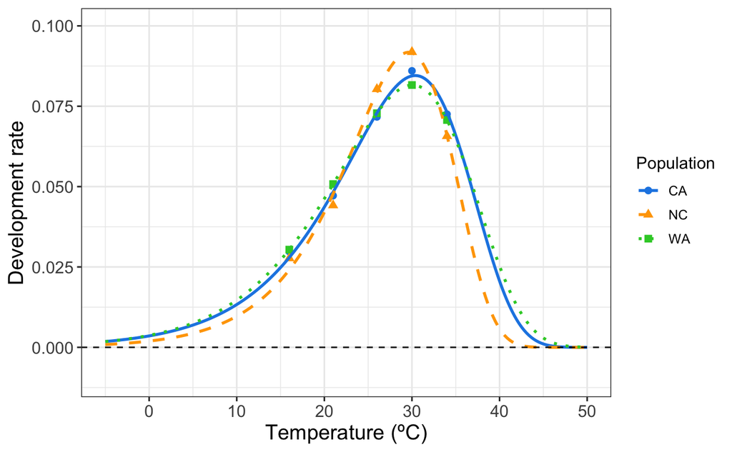

```r
AllWeibull <- ggplot(AllPopWeibull, aes(temp, rate, group = Population, color = Population, linetype= Population, shape = Population)) +
  geom_point(aes(temp, rate, group = Population, color = Population), AllPopPoints, size = 2.25) +
  geom_line(aes(temp, .fitted), size = 1) +
  theme_bw(base_size = 12) +
  labs(x = 'Temperature (ºC)',
       y = 'Development rate',) +
  font("xy", size = 15)+
  font("x.text", size = 12)+
  font("y.text", size = 12)+
  ylim(-.01, .1)+
  geom_hline(aes(yintercept = 0), linetype = 2)  +
  scale_color_manual(values = c("#1E88E5", "orange", "lime green")) +
  scale_linetype_manual(values = c("solid", "dashed", "dotted"))

AllWeibull
```

```r
ggsave("~/Desktop/GitHub/Pieris/Thesis/AllPopsWeibull.png", AllWeibull, width = 8, height = 5)
```

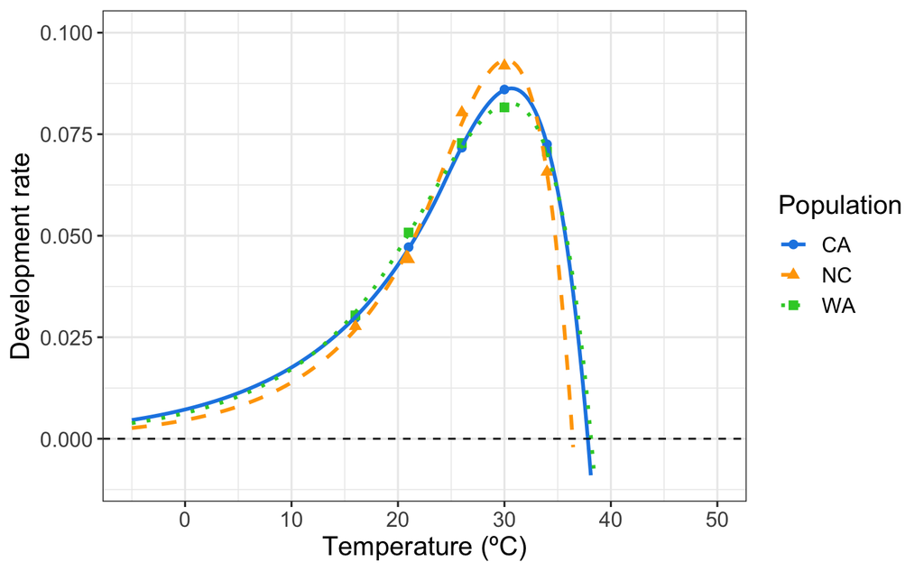

```r
AllRezende <- ggplot(AllPopRezende, aes(temp, rate, group = Population, color = Population, shape = Population, linetype = Population)) +
  geom_point(aes(temp, rate, group = Population, color = Population), AllPopPoints, size = 2.25) +
  geom_line(aes(temp, .fitted), size = 1) +
  theme_bw(base_size = 12) +
  labs(x = 'Temperature (ºC)',
       y = 'Development rate') +
  font("xy", size = 15)+
  font("x.text", size = 12)+
  font("y.text", size = 12)+
  font("legend.title", size= 15)+
  font("legend.text", size = 12)+
  ylim(-.01, .1)+
  geom_hline(aes(yintercept = 0), linetype = 2)  +
  scale_color_manual(values = c("#1E88E5", "orange", "lime green"))+
  scale_linetype_manual(values = c("solid", "dashed", "dotted"))

AllRezende
```

```r
ggsave("~/Desktop/GitHub/Pieris/Thesis/AllPopsRezende.png", AllRezende, width = 8, height = 5)
```

# 2. April and August NC Data

## Load in our April and August temp data

```r
april <- read.csv("~/Desktop/GitHub/Pieris/North_Carolina/NC_Larval_and_Realistic_Temps/Data/simulated_36_-79_2_d_2022_4_1_5_31_inbetween.csv", header = TRUE)

august <- read.csv("~/Desktop/GitHub/Pieris/North_Carolina/NC_Larval_and_Realistic_Temps/Data/simulated_36_-79_2_d_2022_8_1_8_31_inbetween.csv", header = TRUE)
```

## Create our output datafile

### Cut down by hour

```r
aprilhourly <- april[april$V7 == 0, ]
augusthourly <- august[august$V7 == 0, ]
```

```r
apriltemps <- tibble(Mean.Temp = aprilhourly$V1) ## Needs to be the same column name as in the model object

augusttemps <- tibble(Mean.Temp = augusthourly$V1)
```

## TANGENT: Graph temp distributions compared to weibull curve (Not doing yet)

```r
histtemps <- tibble(Mean.Temp = seq((-5), 50, length.out = 200))

solopreds <- augment(fitmodweibull, newdata = histtemps)
```

```r
weibullwithhist <-ggplot(data = solopreds) +
  geom_line(aes(x = Mean.Temp, y = .fitted), color = "gray") +
  geom_point(aes(x = Mean.Temp,y = Dev.Rate), data = pupalmeansyes, color = "black") +
  theme_bw() +
  labs(x = 'Temperature (ºC)') +
  scale_y_continuous(name = "Development Rate",
                     sec.axis = sec_axis(trans = ~., name = "Frequency of observed temperatures")) +
  geom_histogram(data = apriltemps, aes(x = Mean.Temp, y = ..count.. / 5000), color = "lime green",
                 fill = "lime green", alpha = .5) +
  geom_histogram(data = augusttemps, aes(x = Mean.Temp, y = ..count.. / 5000), color = "turquoise",
                 fill = "turquoise", alpha = .5)


weibullwithhist
```

```r
ggsave("~/Desktop/GitHub/Pieris/Figures/weibullwithhist.png", weibullwithhist, width = 8, height = 5)
```

## Get predictions into that datafile

```r
aprilpreds <- augment(NCfitmodweibull, newdata = apriltemps)
```

```
Error in data.frame(..., check.names = FALSE) :
  arguments imply differing number of rows: 1462, 5
```

```r
aprilpreds1 <- augment(NCfitmodrezende, newdata = apriltemps)

augustpreds1 <- augment(NCfitmodrezende, newdata = augusttemps)


aprilpreds1$.fitted <- aprilpreds1$.fitted / 24

augustpreds1$.fitted <- augustpreds1$.fitted / 24
```

## Add dev rate until we hit 1, then extract total number of hours (Not doing yet)

```r
apriloutput <- data.frame(hour = 1, .fitted = aprilpreds[1, 2])

for(i in 1:length(aprilpreds$.fitted)){
  if(apriloutput[i, 2] >= 1){
    print(apriloutput[i, 1] / 24)
  } else if(apriloutput[i, 2] < 1){
    newoutput <- data.frame(hour = i+1, .fitted = (apriloutput[i, 2] + aprilpreds[i+1, 2]))
    apriloutput <- rbind(apriloutput, newoutput)
  }
}
```

```r
for(i in 1:length(aprilpreds1$.fitted)){
  if(apriloutput1[i, 2] >= 1){
    print(apriloutput1[i, 1] / 24)
  } else if(apriloutput1[i, 2] < 1){
    newoutput <- data.frame(hour = i+1, .fitted = (apriloutput1[i, 2] + aprilpreds1[i+1, 2]))
    apriloutput1 <- rbind(apriloutput1, newoutput)
  }
}
```

```
[1] 32.66667
```

```
Error in if (apriloutput1[i, 2] >= 1) { :
  missing value where TRUE/FALSE needed
```

```r
augustoutput <- data.frame(hour = 1, .fitted = augustpreds[1, 2])

for(i in 1:length(augustpreds$.fitted)){
  if(augustoutput[i, 2] >= 1){
    print(augustoutput[i, 1] / 24)
  } else if(augustoutput[i, 2] < 1){
    newoutput <- data.frame(hour = i+1, .fitted = (augustoutput[i, 2] + augustpreds[i+1, 2]))
    augustoutput <- rbind(augustoutput, newoutput)
  }
}
```

```r
for(i in 1:length(augustpreds1$.fitted)){
  if(augustoutput1[i, 2] >= 1){
    print(augustoutput1[i, 1] / 24)
  } else if(augustoutput1[i, 2] < 1){
    newoutput <- data.frame(hour = i+1, .fitted = (augustoutput1[i, 2] + augustpreds1[i+1, 2]))
    augustoutput1 <- rbind(augustoutput1, newoutput)
  }
}
```

```
[1] 13.125
```

```
Error in if (augustoutput1[i, 2] >= 1) { :
  missing value where TRUE/FALSE needed
```

## Get predictions into that datafile - hourly

```r
aprilpredstotal <- augment(fitmodweibulltotal, newdata = apriltemps)

augustpredstotal <- augment(fitmodweibulltotal, newdata = augusttemps)


aprilpredstotal$.fitted <- aprilpredstotal$.fitted / 24

augustpredstotal$.fitted <- augustpredstotal$.fitted / 24
```

## Add dev rate until we hit 1, then extract total number of hours

```r
apriloutputtotal <- data.frame(hour = 1, .fitted = aprilpredstotal[1, 2])

for(i in 1:length(aprilpredstotal$.fitted)){
  if(apriloutputtotal[i, 2] >= 1){
    print(apriloutputtotal[i, 1] / 24)
  } else if(apriloutputtotal[i, 2] < 1){
    newoutput <- data.frame(hour = i+1, .fitted = (apriloutputtotal[i, 2] + aprilpredstotal[i+1, 2]))
    apriloutputtotal <- rbind(apriloutputtotal, newoutput)
  }
}
```

```r
augustoutputtotal <- data.frame(hour = 1, .fitted = augustpredstotal[1, 2])

for(i in 1:length(augustpredstotal$.fitted)){
  if(augustoutputtotal[i, 2] >= 1){
    print(augustoutputtotal[i, 1] / 24)
  } else if(augustoutputtotal[i, 2] < 1){
    newoutput <- data.frame(hour = i+1, .fitted = (augustoutputtotal[i, 2] + augustpredstotal[i+1, 2]))
    augustoutputtotal <- rbind(augustoutputtotal, newoutput)
  }
}
```

# 4. Fit all to daily temp means

```r
aprdailymeans <- data.frame(Mean.Temp = 0)

april$V10 <- april$V8 + 1
```

### Get daily mean temperatures

```r
for(i in 1:length(unique(april$V10))){
  subset <- april[april$V10 == i, ]
  meanval <- mean(subset$V1)
  aprdailymeans <- rbind(aprdailymeans, meanval)
}
```

```r
aprdailymeans <- aprdailymeans[2:62, ]

aprdailymeans <- tibble(Temperature = aprdailymeans)
```

## Do the prediction part

```r
aprildailypreds <- augment(NCfitmodweibull, newdata = aprdailymeans)
```

## Add dev rate until we hit 1, then extract total number of days

```r
aprildailyoutput <- data.frame(day = 1, .fitted = aprildailypreds[1, 2])

for(i in 1:length(aprildailypreds$.fitted)){
  if(aprildailyoutput[i, 2] >= 1){
    print(aprildailyoutput[i, 1])
  } else if(aprildailyoutput[i, 2] < 1){
    newoutput <- data.frame(day = i+1, .fitted = (aprildailyoutput[i, 2] + aprildailypreds[i+1, 2]))
    aprildailyoutput <- rbind(aprildailyoutput, newoutput)
  }
}
```

## AUGUST

```r
augdailymeans <- data.frame(Mean.Temp = 0)

august$V10 <- august$V8 + 1
```

```r
for(i in 1:length(unique(august$V10))){
  subset <- august[august$V10 == i, ]
  #print(subset)
  meanval <- mean(subset$V1)
  augdailymeans <- rbind(augdailymeans, meanval)
}
```

```r
augdailymeans <- augdailymeans[2:32, ]

augdailymeans <- tibble(Temperature = augdailymeans)
```

## Do the prediction part

```r
augustdailypreds <- augment(NCfitmodweibull, newdata = augdailymeans)
```

## Add dev rate until we hit 1, then extract total number of days

```r
augustdailyoutput <- data.frame(day = 1, .fitted = augustdailypreds[1, 2])

for(i in 1:length(augustdailypreds$.fitted)){
  if(augustdailyoutput[i, 2] >= 1){
    print(augustdailyoutput[i, 1])
  } else if(augustdailyoutput[i, 2] < 1){
    newoutput <- data.frame(day = i+1, .fitted = (augustdailyoutput[i, 2] + augustdailypreds[i+1, 2]))
    augustdailyoutput <- rbind(augustdailyoutput, newoutput)
  }
}
```

# 3. Survival curves

```r
survdata$Mean.Temp <- as.character(survdata$Mean.Temp)
survdata$Mean.Temp <- as.numeric(survdata$Mean.Temp)
```

```r
s <- as.data.frame(cbind(survdata$Mean.Temp, survdata$surv.perc))

colnames(s) <- c("temp", "rate")
```

```r
s_fits <- nest(s, data = c(temp, rate)) %>%
  mutate(beta = map(data, ~nls_multstart(rate~beta_2012(temp = temp, a, b, c, d, e),
                                         data = .x,
                                         iter = c(4,4,4,4,4),
                                         start_lower = get_start_vals(.x$temp, .x$rate,
                                                                      model_name = 'beta_2012') - 10,
                                         start_upper = get_start_vals(.x$temp, .x$rate,
                                                                      model_name = 'beta_2012') + 10,
                                         lower = get_lower_lims(.x$temp, .x$rate, model_name = 'beta_2012'),
                                         upper = get_upper_lims(.x$temp, .x$rate, model_name = 'beta_2012'),
                                         supp_errors = 'Y',
                                         convergence_count = FALSE)),

         boatman = map(data, ~nls_multstart(rate~boatman_2017(temp = temp, rmax, tmin, tmax, a, b),
                                             data = .x,
                                             iter = c(4,4,4,4,4),
                                             start_lower = get_start_vals(.x$temp, .x$rate, model_name = 'boatman_2017') - 10,
                                             start_upper = get_start_vals(.x$temp, .x$rate, model_name = 'boatman_2017') + 10,
                                             lower = get_lower_lims(.x$temp, .x$rate, model_name = 'boatman_2017'),
                                             upper = get_upper_lims(.x$temp, .x$rate, model_name = 'boatman_2017'),
                                             supp_errors = 'Y',
                                             convergence_count = FALSE)),

         delong =  map(data, ~nls_multstart(rate~delong_2017(temp = temp, c, eb, ef, tm, ehc),
                                             data = .x,
                                             iter = c(4,4,4,4,4),
                                             start_lower = get_start_vals(.x$temp, .x$rate,
                                                                          model_name = 'delong_2017') - 10,
                                             start_upper = get_start_vals(.x$temp, .x$rate,
                                                                          model_name = 'delong_2017') + 10,
                                             lower = get_lower_lims(.x$temp, .x$rate, model_name = 'delong_2017'),
                                             upper = get_upper_lims(.x$temp, .x$rate, model_name = 'delong_2017'),
                                             supp_errors = 'Y',
                                             convergence_count = FALSE)),

         flinn = map(data, ~nls_multstart(rate~flinn_1991(temp = temp, a,b,c),
                                            data = .x,
                                            iter = c(4,4,4),
                                            start_lower = get_start_vals(.x$temp, .x$rate, model_name = 'flinn_1991') - 10,
                                            start_upper = get_start_vals(.x$temp, .x$rate, model_name = 'flinn_1991') + 10,
                                            lower = get_lower_lims(.x$temp, .x$rate, model_name = 'flinn_1991'),
                                            upper = get_upper_lims(.x$temp, .x$rate, model_name = 'flinn_1991'),
                                            supp_errors = 'Y',
                                            convergence_count = FALSE)),

          gaussian =  map(data, ~nls_multstart(rate~gaussian_1987(temp = temp, rmax, topt, a),
                                             data = .x,
                                             iter = c(4,4,4),
                                             start_lower = get_start_vals(.x$temp, .x$rate,
                                                                          model_name = 'gaussian_1987') - 10,
                                             start_upper = get_start_vals(.x$temp, .x$rate,
                                                                          model_name = 'gaussian_1987') + 10,
                                             lower = get_lower_lims(.x$temp, .x$rate, model_name = 'gaussian_1987'),
                                             upper = get_upper_lims(.x$temp, .x$rate, model_name = 'gaussian_1987'),
                                             supp_errors = 'Y',
                                             convergence_count = FALSE)),

         johnlew =  map(data, ~nls_multstart(rate~johnsonlewin_1946(temp = temp, rO, e, eh, topt),
                                             data = .x,
                                             iter = c(4,4,4,4),
                                             start_lower = get_start_vals(.x$temp, .x$rate,
                                                                          model_name = 'johnsonlewin_1946') - 10,
                                             start_upper = get_start_vals(.x$temp, .x$rate,
                                                                          model_name = 'johnsonlewin_1946') + 10,
                                             lower = get_lower_lims(.x$temp, .x$rate, model_name = 'johnsonlewin_1946'),
                                             upper = get_upper_lims(.x$temp, .x$rate, model_name = 'johnsonlewin_1946'),
                                             supp_errors = 'Y',
                                             convergence_count = FALSE)),

         modified_gauss =  map(data, ~nls_multstart(rate~modifiedgaussian_2006(temp = temp, rmax, topt, a, b),
                                             data = .x,
                                             iter = c(4,4,4,4),
                                             start_lower = get_start_vals(.x$temp, .x$rate,
                                                                          model_name = 'modifiedgaussian_2006') - 10,
                                             start_upper = get_start_vals(.x$temp, .x$rate,
                                                                          model_name = 'modifiedgaussian_2006') + 10,
                                             lower = get_lower_lims(.x$temp, .x$rate, model_name = 'modifiedgaussian_2006'),
                                             upper = get_upper_lims(.x$temp, .x$rate, model_name = 'modifiedgaussian_2006'),
                                             supp_errors = 'Y',
                                             convergence_count = FALSE)),
```

```r
         oneill =  map(data, ~nls_multstart(rate~oneill_1972(temp = temp, rmax, ctmax, topt, q10),
                                             data = .x,
                                             iter = c(4,4,4,4),
                                             start_lower = get_start_vals(.x$temp, .x$rate,
                                                                          model_name = 'oneill_1972') - 10,
                                             start_upper = get_start_vals(.x$temp, .x$rate,
                                                                          model_name = 'oneill_1972') + 10,
                                             lower = get_lower_lims(.x$temp, .x$rate, model_name = 'oneill_1972'),
                                             upper = get_upper_lims(.x$temp, .x$rate, model_name = 'oneill_1972'),
                                             supp_errors = 'Y',
                                             convergence_count = FALSE)),

         pawar =  map(data, ~nls_multstart(rate~pawar_2018(temp = temp, r_tref, e, eh, topt, tref = 20),
                                             data = .x,
                                             iter = c(4,4,4,4),
                                             start_lower = get_start_vals(.x$temp, .x$rate,
                                                                          model_name = 'pawar_2018') - 10,
                                             start_upper = get_start_vals(.x$temp, .x$rate,
                                                                          model_name = 'pawar_2018') + 10,
                                             lower = get_lower_lims(.x$temp, .x$rate, model_name = 'pawar_2018'),
                                             upper = get_upper_lims(.x$temp, .x$rate, model_name = 'pawar_2018'),
                                             supp_errors = 'Y',
                                             convergence_count = FALSE)),

         ratkowsky =  map(data, ~nls_multstart(rate~ratkowsky_1983(temp = temp, tmin, tmax, a, b),
                                             data = .x,
                                             iter = c(4,4,4,4),
                                             start_lower = get_start_vals(.x$temp, .x$rate,
                                                                          model_name = 'ratkowsky_1983') - 10,
                                             start_upper = get_start_vals(.x$temp, .x$rate,
                                                                          model_name = 'ratkowsky_1983') + 10,
                                             lower = get_lower_lims(.x$temp, .x$rate, model_name = 'ratkowsky_1983'),
                                             upper = get_upper_lims(.x$temp, .x$rate, model_name = 'ratkowsky_1983'),
                                             supp_errors = 'Y',
                                             convergence_count = FALSE)),

         sharpeschool =  map(data, ~nls_multstart(rate~sharpeschoolfull_1981(temp = temp, r_tref, e, el, tl, eh, th, tref = 20),
                                             data = .x,
                                             iter = c(4,4,4,4,4,4),
                                             start_lower = get_start_vals(.x$temp, .x$rate,
                                                                          model_name = 'sharpeschoolfull_1981') - 10,
                                             start_upper = get_start_vals(.x$temp, .x$rate,
                                                                          model_name = 'sharpeschoolfull_1981') + 10,
                                             lower = get_lower_lims(.x$temp, .x$rate, model_name = 'sharpeschoolfull_1981'),
                                             upper = get_upper_lims(.x$temp, .x$rate, model_name = 'sharpeschoolfull_1981'),
                                             supp_errors = 'Y',
                                             convergence_count = FALSE)),

         weibull =  map(data, ~nls_multstart(rate~weibull_1995(temp = temp, a, topt, b, c),
                                             data = .x,
                                             iter = c(4,4,4,4),
                                             start_lower = get_start_vals(.x$temp, .x$rate,
                                                                          model_name = 'weibull_1995') - 10,
                                             start_upper = get_start_vals(.x$temp, .x$rate,
                                                                          model_name = 'weibull_1995') + 10,
                                             lower = get_lower_lims(.x$temp, .x$rate, model_name = 'weibull_1995'),
                                             upper = get_upper_lims(.x$temp, .x$rate, model_name = 'weibull_1995'),
                                             supp_errors = 'Y',
                                             convergence_count = FALSE)),
         )

# stack models
s_stack <- select(s_fits, -data) %>%
  pivot_longer(., names_to = 'model_name', values_to = 'fit', beta:weibull)

# get parameters using tidy (no longer working)
s_params <- s_stack %>%
  mutate(., est = map(fit, tidy)) %>%
  select(-fit) %>%
  unnest(est)

# get predictions using augment
s_newdata <- tibble(temp = seq(min(s$temp), max(s$temp), length.out = 100))
s_preds <- s_stack %>%
  mutate(., preds = map(fit, augment, newdata = s_newdata)) %>%
  select(-fit) %>%
  unnest(preds)
```

## Compare models using AIC

```r
AIC(s_fits[[2]][[1]],s_fits[[3]][[1]], s_fits[[4]][[1]], s_fits[[5]][[1]], s_fits[[6]][[1]], s_fits[[7]][[1]], s_fits[[8]][[1]], s_fits[[9]][[1]], s_fits[[10]][[1]], s_fits[[11]][[1]], s_fits[[12]][[1]], s_fits[[13]][[1]])
```

## Graphing all:

```r
ggplot(s_preds, aes(temp, rate)) +
  geom_point(aes(temp, rate), s) +
  geom_line(aes(temp, .fitted), col = 'blue') +
  facet_wrap(~model_name, scales = 'free', ncol = 5) +
  theme_bw(base_size = 12) +
  theme(legend.position = 'none',
        strip.text = element_text(hjust = 0),
        strip.background = element_blank()) +
  labs(x = 'Temperature (ºC)',
       y = 'Survival rate',
       title = 'Model fit comparison') +
  geom_hline(aes(yintercept = 0), linetype = 2)
```

```r
toxaxis_s <- tibble(temp = seq(-5, 50, length.out = 100))

s_preds_two <- s_stack %>%
  mutate(., preds = map(fit, augment, newdata = toxaxis_s)) %>%
  select(-fit) %>%
  unnest(preds)
```

```r
survmodelcomp <- ggplot(s_preds_two[c(501:600, 801:900), ], aes(temp, rate)) +
  geom_point(aes(temp, rate), s, color = "black") +
  geom_line(aes(temp, .fitted, color = model_name)) +
  theme_bw(base_size = 12) +
  labs(x = 'Temperature (ºC)',
       y = 'Survival rate',
       title = 'Model fit comparison',
       color = "Model name") +
  geom_hline(aes(yintercept = 0), linetype = 2) +
  scale_color_manual(values = c("purple", "lime green"))

survmodelcomp
```

```r
ggsave("~/Desktop/GitHub/Pieris/Figures/survmodelcomp.png", survmodelcomp, width = 8, height = 5)
```